# ECON 487 HW6

Tiffany Tian

11/8/2021

```r
library(rpart)
library(rpart.plot)
library(partykit)
library(maptree)
library(plyr)
library(dplyr)
library(tidyr)
library(glmnet)
library(reshape2)

oj <- read.csv("oj.csv")
```

## 1.a

```r
oj$Q <- exp(oj$logmove)
```

## 1.b

```r
df1 <- ddply(oj, c('store','week'), function(x) c(weighted_mean = weighted.mean(x$price, x$Q)))
oj = merge(df1, oj, by = c("store", "week"))
```

## 2.a-d

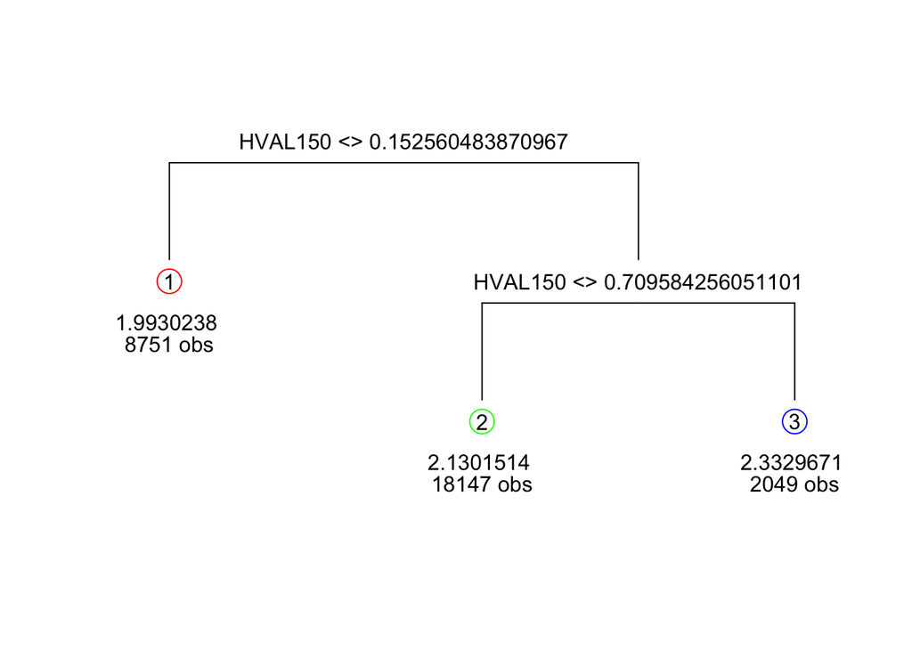

```r
oj_dom <- oj %>%
  filter(brand == "dominicks")

# Create a data frame from the existing one (with weighted mean merged back in)
# which will then be passed into rpart (tree partitioning algorithm).
dataToPass <- oj[, c("weighted_mean","AGE60","EDUC","ETHNIC","INCOME","HHLARGE",
                     "WORKWOM","HVAL150","SSTRDIST","SSTRVOL","CPDIST5","CPWVOL5")]

# Fit the tree
fit <- rpart(as.formula(weighted_mean ~ .), data = dataToPass,
             method = "anova", cp = 0.007)

# Draw the tree
draw.tree(fit)
```

```r
# Assign Leaves to observations
dataToPass$leaf = fit$where
oj_leaf <- merge(oj, dataToPass) %>% unique()
```

## 3.a

```r
oj_prices <-oj[,1:6]
oj_wide <- dcast(oj_prices, store + week ~ brand)
colnames(oj_wide)[3] <- "P_Dom"
colnames(oj_wide)[4] <- "P_MM"
colnames(oj_wide)[5] <- "P_Trop"
oj_cross_leaf <- merge(oj_leaf, oj_wide, by=c("week","store"))

reg_trop <- lm(logmove~log(price)*as.factor(leaf)*feat,
          data = oj_cross_leaf %>% filter(brand == "tropicana"))
summary(reg_trop)
```

```
##
## Call:
## lm(formula = logmove ~ log(price) * as.factor(leaf) * feat, data = oj_cross_leaf %>%
##     filter(brand == "tropicana"))
##
## Residuals:
##     Min      1Q  Median      3Q     Max
## -2.9491 -0.3517 -0.0052  0.3320  3.1820
##
## Coefficients:
##                                   Estimate Std. Error t value Pr(>|t|)
## (Intercept)                      11.503128   0.065341 176.047  < 2e-16 ***
## log(price)                       -2.700204   0.061429 -43.956  < 2e-16 ***
## as.factor(leaf)4                 -0.374992   0.078620  -4.770 1.87e-06 ***
## as.factor(leaf)5                  0.336931   0.139131   2.422   0.0155 *
## feat                              1.767029   0.130017  13.591  < 2e-16 ***
## log(price):as.factor(leaf)4       0.702300   0.073330   9.577  < 2e-16 ***
## log(price):as.factor(leaf)5       0.735226   0.123937   5.932 3.09e-09 ***
## log(price):feat                  -1.390388   0.144018  -9.654  < 2e-16 ***
## as.factor(leaf)4:feat             0.035959   0.157143   0.229   0.8190
## as.factor(leaf)5:feat            -0.584803   0.282415  -2.071   0.0384 *
## log(price):as.factor(leaf)4:feat -0.002055   0.173114  -0.012   0.9905
## log(price):as.factor(leaf)5:feat  0.628017   0.304170   2.065   0.0390 *
## ---
## Signif. codes:  0 '***' 0.001 '**' 0.01 '*' 0.05 '.' 0.1 ' ' 1
##
## Residual standard error: 0.5337 on 9637 degrees of freedom
## Multiple R-squared:  0.6038, Adjusted R-squared:  0.6034
## F-statistic:  1335 on 11 and 9637 DF,  p-value: < 2.2e-16
```

## 3.b

```r
#leaf specific regressions
temp <- oj_cross_leaf %>%
  select(c("price", "brand", "store", "week",
           "logmove","leaf", "feat")) %>%
  reshape(timevar = "brand",
          idvar = c("store", "week", "leaf"),
          direction = "wide")

# Create matrices
elasticity_2 <- elasticity_4 <- elasticity_5 <- data.frame(matrix(NA, 3, 3)) %>%
  `colnames<-`(c("Dom","MM","Trop")) %>%
  `rownames<-`(c("Dom","MM","Trop"))
leaves = c(2, 4, 5)
# Create list to store elasticities
dom = list()
mm = list()
trop = list()

for (i in 1:3){
  temp_df <- temp %>% filter(leaf == leaves[i])
  reg_dom = lm(logmove.dominicks ~ log(price.dominicks)*feat.dominicks +
              log(price.minute.maid)*feat.minute.maid +
              log(price.tropicana)*feat.tropicana, data = temp_df)
  reg_mm = lm(logmove.minute.maid ~ log(price.dominicks)*feat.dominicks +
              log(price.minute.maid)*feat.minute.maid +
              log(price.tropicana)*feat.tropicana, data = temp_df)
  reg_trop = lm(logmove.tropicana ~ log(price.dominicks)*feat.dominicks +
              log(price.minute.maid)*feat.minute.maid +
              log(price.tropicana)*feat.tropicana, data = temp_df)

  dom[[i]] = c(coef(reg_dom)[2], coef(reg_dom)[4], coef(reg_dom)[6])
  mm[[i]] = c(coef(reg_mm)[2], coef(reg_mm)[4], coef(reg_mm)[6])
  trop[[i]] = c(coef(reg_trop)[2], coef(reg_trop)[4], coef(reg_trop)[6])
}

elasticity_2$Dom = dom[[1]]
elasticity_4$Dom = dom[[2]]
elasticity_5$Dom = dom[[3]]

elasticity_2$MM = mm[[1]]
elasticity_4$MM = mm[[2]]
elasticity_5$MM = mm[[3]]

elasticity_2$Trop = trop[[1]]
elasticity_4$Trop = trop[[2]]
elasticity_5$Trop = trop[[3]]

elasticity_2
```

```
##             Dom         MM       Trop
## Dom  -2.9992313  0.5892053  0.2406776
## MM    0.9987811 -2.8869054  0.2673389
## Trop -0.4388592  0.5446678 -2.7943234
```

```r
elasticity_4
```

```
##             Dom         MM       Trop
## Dom  -2.8179392  0.6421862  0.1932240
## MM    1.1613255 -2.3576863  0.3839338
## Trop -0.1902214  0.6188453 -2.1068371
```

```r
elasticity_5
```

```
##             Dom         MM        Trop
## Dom  -3.1218003  0.2132436 -0.01305233
## MM    0.8630777 -2.0289175  0.17178388
## Trop -0.3477896  0.3154877 -1.97972812
```

## 4.b

1. What does this imply about differences in markups within high versus low elasticity stores across brands?

This means that stores in high own-price elasticity has low markups because their customers are overall more sensitive to the price of their own brand.

2. Can you say anything about what this means for the timing of sales? Should they occur at the same or different times across stores?

This means that for the timing of sales should occur at the same time across stores, especially for stores with high own-price elasticity.

## 5

Since s_2/p_2 > s_1/p_1

then (θs_2)/p_2 > (θs_1)/p_1

(θs_2)/p_2 - 1 > (θs_1)/p_1 - 1

p_1(θs2/p2 - 1) > p_1(θs1/p1 - 1)

Since p_2 > p_1,

p_2((θs_2)/p_2 - 1) > p_1 ((θs_1)/p_1 - 1)

(θs_2-p_2) > (θs_1 - p_1)

(θs_2-p_2) - (θs_1 - p_1) > 0